[figure not shown]

# Professor: ANGEL CASTELLANOS GONZALEZ

# Assignment #2

### **Done By:**

### **1. Jorge Alarcon**

### **2. Cecilia De Brun**

### **3. Hani Eid**

### The best score we got was: **0.8187**

Initialization

Import libraries

```r
library(caTools)
library(ggplot2)
library(googleVis)
library(randomForest)
library(caret)
library(xgboost)
library(data.table)
library(car)
library(dummies)
library(LogicReg)
library(RWeka)
library(lubridate)
library(plyr)
library(e1071)
library(arm)
library(abind)
library(coda)
#library(h2o)
#localH2O <- h2o.init(nthreads = -1)
#h2o.init()
```

```r
training_data<- read.csv("Data/Training_data.csv")
test_data<- read.csv("Data/Test_data.csv")
labels_data<- read.csv("Data/Labels.csv")
```

We will merge training and labels data frames to create the data frame train

```r
train<- merge(labels_data, training_data)
str(train)
```

```
## 'data.frame':    59400 obs. of  41 variables:
##  $ id                   : int  0 1 2 3 4 5 6 7 8 9 ...
##  $ status_group         : Factor w/ 3 levels "functional","functional needs repair",..: 3 1 1 1 3 1 3 1 3 3 ...
##  $ amount_tsh           : num  0 0 0 10 0 50 0 0 0 0 ...
##  $ date_recorded        : Factor w/ 356 levels "2002-10-14","2004-01-07",..: 230 39 61 341 56 32 206 57 72 104 ...
##  $ funder               : Factor w/ 1898 levels "","0","A/co Germany",..: 1635 1502 840 438 213 1272 458 1831 1831 281 ...
##  $ gps_height           : int  0 1978 0 1639 0 28 0 0 0 0 ...
##  $ installer            : Factor w/ 2146 levels "","-","0","A.D.B",..: 1808 1692 1001 230 278 1462 572 565 289 376 ...
##  $ longitude            : num  33.1 34.8 36.1 37.1 36.2 ...
##  $ latitude             : num  -5.12 -9.4 -6.28 -3.19 -6.1 ...
##  $ wpt_name             : Factor w/ 37400 levels "24","A Kulwa",..: 29563 32437 1067 446 2598 20291 28857 4091 9067 35289 ...
##  $ num_private          : int  0 0 0 0 0 0 0 0 0 0 ...
##  $ basin                : Factor w/ 9 levels "Internal","Lake Nyasa",..: 4 7 9 6 9 9 1 7 9 5 ...
##  $ subvillage           : Factor w/ 19288 levels "","'A' Kati",..: 9076 8912 17876 18716 8625 13587 14808 13632 10151 10823 ...
##  $ region               : Factor w/ 21 levels "Arusha","Dar es Salaam",..: 20 4 3 7 3 15 18 3 3 5 ...
```

[output cut: 27 more lines]

We look at the distribution of our dependent variable through the sample

```r
table(train$status_group)
```

```
##
##              functional functional needs repair          non functional
##                   32259                    4317                   22824
```

As proportions

```r
proportions_status<-round(prop.table(table(train$status_group))*100, 1)
print(proportions_status)
```

```
##
##              functional functional needs repair          non functional
##                    54.3                     7.3                    38.4
```

Let’s visualize a matrix between the quantity of water and the status

```r
prop.table(table(train$quantity, train$status_group), margin = 1)
```

```
##
##                 functional functional needs repair non functional
##   dry          0.025136087             0.005923791    0.968940122
##   enough       0.652323269             0.072319653    0.275357078
##   insufficient 0.523233525             0.095842422    0.380924053
##   seasonal     0.574074074             0.102716049    0.323209877
##   unknown      0.269961977             0.017743980    0.712294043
```

Create bar plot for variable quantity. From this graph we can see how the quantity of water is related with the waterpoints functionality since when they are dry, the proportion of non fcuntional water point is almost 100%, while when the water is = ‘enough’, Functionality increases.

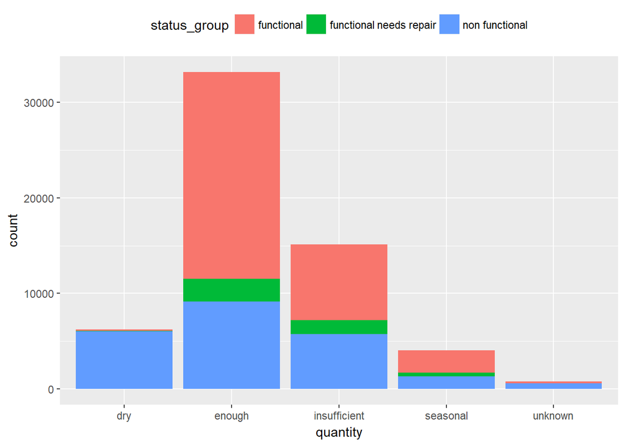

```r
plot_quantity<-qplot(quantity, data=train, geom="bar", fill=status_group) +
  theme(legend.position = "top")
print(plot_quantity)
```

```r
plot_quality <- qplot(quality_group, data=train, geom="bar", fill=status_group) +
  theme(legend.position = "top")
```

Now we are going to subset a histogram for `construction_year` grouped by `status_group` when construction_year is larger than 0

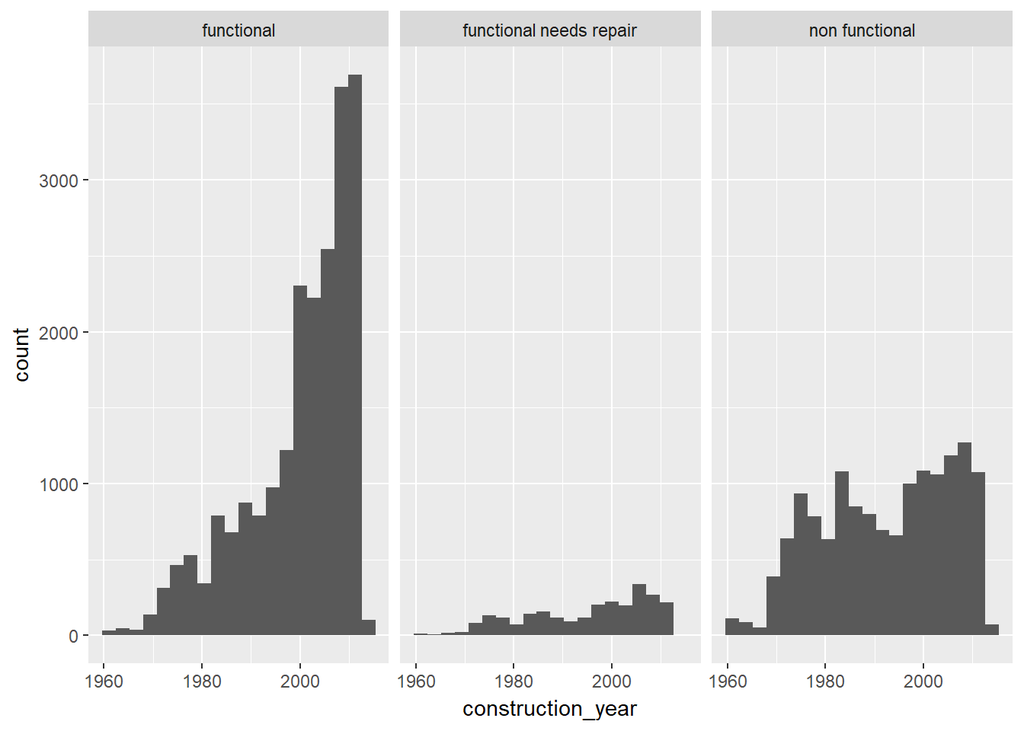

```r
plot_const.year<-ggplot(subset(train, construction_year > 0), aes(x = construction_year)) +
  geom_histogram(bins = 20) +
  facet_grid( ~ status_group)
print(plot_const.year)
```

We decided to create a matrix correlation in order to study the presence of strong correlations between variables. We do this to ensure that the variables we include in the logistic models don´t have repeated information.

```r
indexes <- sapply(train , is.numeric)
train_numeric <- train[,indexes]
correlations_year <- cor(y=train_numeric$construction_year, x=train_numeric, use = 'pairwise.complete.obs')
sum(is.na(train$construction_year))
```

```
## [1] 0
```

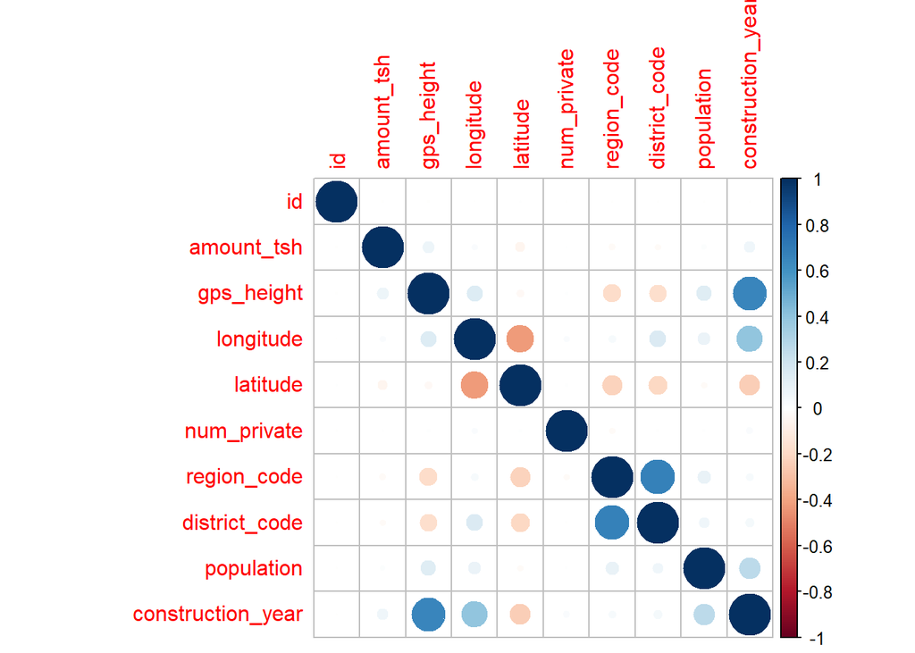

```r
corrplot::corrplot(cor(train_numeric[,-25]))
```

Feature Enginer

The installer variable has a lot of levels, many of which are the result of mispelling when inputing the data. For this reason, we will choose the more relevant variables and group them by some specific characters. Specifically, we transform ´installer´ variable into lowercase and took the first 3 letters as a sub string

```r
summary(train$installer)
```

```
##                           DWE
##                         17402                          3655
##                    Government                           RWE
##                          1825                          1206
##                         Commu                        DANIDA
##                          1060                          1050
##                          KKKT                        Hesawa
##                           898                           840
##                             0                          TCRS
##                           777                           707
##            Central government                           CES
##                           622                           610
##                     Community                         DANID
##                           553                           552
##              District Council                        HESAWA
##                           551                           539
##                           LGA                  World vision
##                           408                           408
##                        WEDECO                         TASAF
##                           397                           396
##              District council                         Gover
##                           392                           383
##                         AMREF                         TWESA
##                           329                           316
##                            WU                          Dmdd
##                           301                           287
##                          ACRA                  World Vision
##                           278                           270
##                          SEMA                            DW
##                           249                           246
##                         OXFAM                            Da
##                           234                           224
##                          Gove                 Idara ya maji
##                           222                           222
##                        UNICEF    Sengerema Water Department
##                           222                           214
##                     Kiliwater                          FinW
##                           210                           208
##                         NORAD                            DH
##                           208                           202
```

[output cut: 45 more lines]

```
##                           100                            98
##                        Unisef                            Go
##                            98                            97
##                            Ki                        OXFARM
##                            97                            96
##                    World Bank                         Roman
##                            95                            94
##                         Angli                           VWC
##                            92                            91
##     District water department                          DMDD
##                            89                            89
##                         Missi                             H
##                            87                            86
##                         Shipo                       (Other)
##                            86                         12250
```

```r
train$install_3 <- substr(tolower(train$installer),1,3)
train$install_3[train$install_3 %in% c(" ", "", "0", "_", "-")] <- "other"
```

Take the top 15 substrings from above by occurance frequency

```r
install_top_15 <- names(summary(as.factor(train$install_3)))[1:15]
train$install_3[!(train$install_3 %in% install_top_15)] <- "other"
train$install_3 <- as.factor(train$install_3)
```

Table of the install_3 variable vs the status of the pumps

```r
table(train$install_3, train$status_group)
```

```
##
##         functional functional needs repair non functional
##   cen          263                      26            783
##   ces          538                       1             71
##   com         1140                      92            449
##   dan         1042                      95            545
##   dis          529                     101            744
##   dwe         9454                    1622           6356
##   fin          127                      34            641
##   gov          945                     296           1427
##   hes          791                      54            557
##   kkk          568                      78            517
##   other      15358                    1583           9033
##   rwe          334                     140            818
##   tas          307                      37            167
##   tcr          305                      43            386
##   wor          558                     115            330
```

```r
# As row-wise proportions, install_3 vs status_group
prop.table(table(train$install_3, train$status_group), margin = 1)
```

```
##
##          functional functional needs repair non functional
##   cen   0.245335821             0.024253731    0.730410448
##   ces   0.881967213             0.001639344    0.116393443
##   com   0.678167757             0.054729328    0.267102915
##   dan   0.619500595             0.056480380    0.324019025
##   dis   0.385007278             0.073508006    0.541484716
##   dwe   0.542335934             0.093047269    0.364616797
##   fin   0.158354115             0.042394015    0.799251870
##   gov   0.354197901             0.110944528    0.534857571
##   hes   0.564194009             0.038516405    0.397289586
##   kkk   0.488392089             0.067067928    0.444539983
##   other 0.591283591             0.060945561    0.347770848
##   rwe   0.258513932             0.108359133    0.633126935
##   tas   0.600782779             0.072407045    0.326810176
##   tcr   0.415531335             0.058583106    0.525885559
##   wor   0.556331007             0.114656032    0.329012961
```

Create install_3 for the test set using same top 15 from above

```r
test_data$install_3 <- substr(tolower(test_data$installer),1,3)
test_data$install_3[test_data$install_3 %in% c(" ", "", "0", "_", "-")] <- "other"
test_data$install_3[!(test_data$install_3 %in% install_top_15)] <- "other"
test_data$install_3 <- as.factor(test_data$install_3)
```

The variable ´funders´ presents the same problems as installer, so we will follow the same procedure. Create the same for funders through the creation of the variable funder_3 for the train set using same top 15 from above

```r
summary(train$funder)
```

```
##         Government Of Tanzania
##                           9084                           3635
##                         Danida                         Hesawa
##                           3114                           2202
##                          Rwssp                     World Bank
##                           1374                           1349
##                           Kkkt                   World Vision
##                           1287                           1246
##                         Unicef                          Tasaf
##                           1057                            877
##               District Council                            Dhv
##                            843                            829
##             Private Individual                           Dwsp
##                            826                            811
##                              0                          Norad
##                            777                            765
##                Germany Republi                           Tcrs
##                            610                            602
##              Ministry Of Water                          Water
##                            590                            583
##                            Dwe                    Netherlands
##                            484                            470
##                          Hifab                            Adb
##                            450                            448
##                            Lga                          Amref
##                            442                            425
##                     Fini Water                          Oxfam
##                            393                            359
##                       Wateraid                      Rc Church
##                            333                            321
##                            Isf                          Rudep
##                            316                            312
##                        Mission                        Private
##                            301                            295
##                          Jaica                          Roman
##                            280                            275
## Rural Water Supply And Sanitat                           Adra
##                            270                            263
##                      Ces(gmbh)                           Jica
##                            260                            259
```

[output cut: 45 more lines]

```
##                            108                            107
##                      Villagers                             Ru
##                            106                            105
##                Village Council  Halmashauri Ya Wilaya Sikonge
##                            105                            102
##                        Germany                            Hsw
##                            101                            101
##                            Twe                            Idc
##                             97                             92
##                          Tanza                          Missi
##                             88                             87
##                              H                          Mdrdp
##                             86                             86
##                           Undp                        (Other)
##                             86                          11757
```

```r
train$funder_3 <- substr(tolower(train$funder),1,3)
train$funder_3[train$funder_3 %in% c(" ", "", "0", "_", "-")] <- "other"

#Take the top 15 substrings from above by occurance frequency
funder_top_15 <- names(summary(as.factor(train$funder_3)))[1:15]
train$funder_3[!(train$funder_3 %in% funder_top_15)] <- "other"
train$funder_3 <- as.factor(train$funder_3)

#Table of the funder_3 variable vs the status of the pumps
table(train$funder_3, train$status_group)
```

```
##
##         functional functional needs repair non functional
##   dan         1713                     159           1245
##   dhv          478                      62            351
##   dis          379                      46            420
##   dws          387                     240            233
##   fin          144                      35            662
##   gov         3738                     704           4681
##   hes          943                     232           1041
##   kkk          866                      82            592
##   other      18635                    2098          10650
##   pri          945                      26            175
##   rws          828                     110            468
##   tas          607                      77            376
##   uni          686                     112            404
##   wat          612                     106            419
##   wor         1298                     228           1107
```

```r
# As row-wise proportions, funder_3 vs status_group
prop.table(table(train$funder_3, train$status_group), margin = 1)
```

```
##
##         functional functional needs repair non functional
##   dan   0.54956689              0.05101059     0.39942252
##   dhv   0.53647587              0.06958474     0.39393939
##   dis   0.44852071              0.05443787     0.49704142
##   dws   0.45000000              0.27906977     0.27093023
##   fin   0.17122473              0.04161712     0.78715815
##   gov   0.40973364              0.07716760     0.51309876
##   hes   0.42554152              0.10469314     0.46976534
##   kkk   0.56233766              0.05324675     0.38441558
##   other 0.59379282              0.06685148     0.33935570
##   pri   0.82460733              0.02268761     0.15270506
##   rws   0.58890469              0.07823613     0.33285917
##   tas   0.57264151              0.07264151     0.35471698
##   uni   0.57071547              0.09317804     0.33610649
##   wat   0.53825858              0.09322779     0.36851363
##   wor   0.49297379              0.08659324     0.42043297
```

```r
test_data$funder_3 <- substr(tolower(test_data$funder),1,3)
test_data$funder_3[test_data$funder_3 %in% c(" ", "", "0", "_", "-")] <- "other"
test_data$funder_3[!(test_data$funder_3 %in% funder_top_15)] <- "other"
test_data$funder_3 <- as.factor(test_data$funder_3)
```

We have splited the variable date_recorded into the variable month in the train and test dataset

```r
train$month <- lubridate::month(train$date_recorded)
test_data$month <- lubridate::month(test_data$date_recorded)
```

We convert the variables basin, payment_type and status_group as a factors

```r
train$payment_type <- as.factor(train$payment_type)
train$basin <- as.factor(train$basin)
train$status_group <- as.factor(train$status_group)
```

In order to make a proper NA imputation for construction_year we decided to use a linear model We removed from the model extraction_type_group and latitude because of multicollinearity. We decided to not use it because the results obtained with the imputation reduce performance of the model

```r
# train_full_const <- subset(train, subset = construction_year != 0)
# train_with0_const <- subset(train, subset = construction_year == 0)
#or,
#train[train$construction_year!=0,]


# model_linear_const <- lm(construction_year ~ longitude +
#                            quantity + waterpoint_type + install_3 +
#                            payment_type + permit, data = train_full_const)
# multicollinearity<-vif(model_linear_const)
# multicollinearity
#
# train_with0_const$construction_year <- round(predict(model_linear_const, train_with0_const),0)
# train <- rbind(train_full_const, train_with0_const)
```

###Predictions through random forest!!

First Random Forest only including the variables proposed by datacamp course

```r
#
# model_forest <- randomForest(as.factor(status_group) ~ longitude + latitude +
#                                extraction_type_group + quantity + waterpoint_type +
#                                construction_year + install_3,
#                              data = train, importance = TRUE,
#                              ntree = 15, nodesize = 3)
```

Predict first model using in the training set

```r
# pred_forest_train <- predict(model_forest, train)
# importance(model_forest)
# confusionMatrix(pred_forest_train, train$status_group)
#
# #variables importance
# importance(model_forest)
# varImpPlot(model_forest)
#
# # Predict using the test values
# pred_forest_test <- predict(model_forest, test_data)
```

Second Random Forest, we decided to include some variables such as population and water_quality that we consider important for the prediction of the dependent variable

```r
 # model_forest_2 <- randomForest(as.factor(status_group) ~ longitude + latitude +
 #                                 extraction_type_group + quantity + waterpoint_type +
 #                                 construction_year + install_3 + population + water_quality,
 #                              data = train, importance = TRUE,
 #                              ntree = 15, nodesize = 3,
 #                              seed = 42, do.trace=20)
```

Predict second random forest using the training values

```r
# pred_forest_train <- predict(model_forest_2, train)
# importance(model_forest_2)
# confusionMatrix(pred_forest_train, train$status_group)
#
# # Predict using the test values
# pred_forest_test <- predict(model_forest_2, test_data)
```

We decided to exclude some variables due to a large amount of NAs and the difficulty make an NA imputations through a prediction of the real values

```r
train$recorded_by <- NULL
train$ward <- NULL
train$subvillage <- NULL
train$scheme_name <- NULL
train$wpt_name <- NULL
train$date_recorded <- NULL
train$funder <- NULL
train$installer <- NULL
feature.names <- names(train)
```

We develop a third random forest that includes new variables such as funder_3 or month increasing the performance of the model to 0.8

```r
# model_forest_3 <- randomForest(as.factor(status_group) ~ longitude + latitude +
#                                  extraction_type_group + quantity + waterpoint_type +
#                                  install_3 + population + water_quality +
#                                  funder_3 + month, do.trace=50,
#                                data = train, importance = TRUE,
#                                ntree = 50, nodesize = 2,
#                               seed = 42)
```

We decided to create a random forest at the top of a bayesian of logistic regression. To do it, firstly we have dummified the dependent variable to compute the logit models and split the sample for the models.

```r
# train$functional <- as.factor(ifelse(train$status_group=='functional',1,0))
# train$functional_nr <- as.factor(ifelse(train$status_group=='functional needs repair',1,0))
# train$non_functional <- as.factor(ifelse(train$status_group=='non functional',1,0))
```

Secondly, we have created three Bayesian regression model, one per each category

```r
# start_time <- Sys.time()
# func <- train(functional ~ longitude +
#                                  extraction_type_group + quantity + waterpoint_type +
#                                  install_3 + population + water_quality +
#                                  funder_3 + month, method = "bayesglm",data=train)
#
#
#
# func_nr <- train(functional_nr ~ longitude + latitude +
#                                  extraction_type_group + quantity + waterpoint_type +
#                                  install_3 + water_quality +
#                                  funder_3 + month, method = "bayesglm",data=train)
#
#
# non_func <- train(non_functional ~ longitude + latitude +
#                                  extraction_type_group + quantity + waterpoint_type +
#                                  install_3 + population + water_quality +
#                                  funder_3 + month, method = "bayesglm",data=train)
#
# end_time <- Sys.time()
# end_time - start_time
```

We predict bayesian in train data

```r
# pred_logit_func <- predict(func, train)
#
# pred_logit_func_nr <- predict(func_nr, train)
#
# pred_logit_non_func <- predict(non_func, train)
#
# table(train$status_group,pred_logit_func)
#
# table(train$status_group,pred_logit_func_nr)
#
# table(train$status_group,pred_logit_non_func)
```

We combine the results of the predicction as three new variables to be used by the random forest

```r
# train <- cbind(train, pred_logit_func, pred_logit_func_nr, pred_logit_non_func)
```

We develop a function to create a training and validation sets to run cross validation later

```r
#
# splitdf <- function(dataframe, seed=NULL) {
#   if (!is.null(seed)) set.seed(seed)
#     index <- 1:nrow(dataframe)
#     trainindex <- sample(index, trunc(length(index)/1.5))
#     trainset <- dataframe[trainindex, ]
#     testset <- dataframe[-trainindex, ]
#     list(trainset=trainset,testset=testset)
# }
# splits <- splitdf(train, seed=1)
# training <- splits$trainset
# validation <- splits$testset
```

Now we have created a fourth random forest at top of the bayesian predictions that not improve the results of the previous model

```r
# model_forest_4 <- randomForest(as.factor(status_group) ~ longitude + latitude +
#                                  extraction_type_group + quantity + waterpoint_type +
#                                  install_3 + population + water_quality +
#                                  funder_3 + month + pred_logit_func + pred_logit_func_nr + pred_logit_non_func,
#                                do.trace=100,
#                                data = train, importance = TRUE,
#                                ntree = 500, nodesize = 2,
#                               seed = 42)
```

```r
# start_time <- Sys.time()
# model_forest_5 <- randomForest(status_group ~ longitude + latitude +
#                                  extraction_type_class + quantity + waterpoint_type +
#                                  install_3 + population + water_quality +
#                                  funder_3 + month + basin + amount_tsh + construction_year +
#                                  gps_height + payment + source + region_code + district_code,
#                                do.trace=100,
#                                data = training, importance = TRUE,
#                                ntree = 500, nodesize = 3,
#                               seed = 42)
# end_time <- Sys.time()
# end_time - start_time
```

We tried anothe random forest with the package h2o but didn’t improve previuos results

```r
# train.h2o <- as.h2o(training)
# test.h2o <- as.h2o(test_data)
# validation.h20 <- as.h2o(validation)
#
# rforest.model <- h2o.randomForest(x=c('longitude', 'latitude', 'extraction_type_group',
#                                       'quantity', 'waterpoint_type',
#                                  'install_3', 'population', 'water_quality',
#                                  'funder_3', 'month'),y='status_group',  training_frame = train.h2o,
#                                   ntrees = 1500, mtries = 3, nfolds = 3,validation_frame = validation.h20,
#                                    max_depth = 10, seed = 42)
#
# rforest.model
```

Another example Random Forest 5 (bayesian with random forest at top) 0.8041

```r
# model_forest_5 <- randomForest(as.factor(status_group) ~ longitude + latitude +
#                                  extraction_type_group + quantity + waterpoint_type +
#                                  install_3 + population + water_quality +
#                                  funder_3 + month + pred_logit_func + pred_logit_func_nr + pred_logit_non_func,
#                                do.trace=100,
#                                data = training, importance = TRUE,
#                                ntree = 500, nodesize = 2,
#                               seed = 42)
```

Also we have tried a random forest using caret package. It takes 23 minutes and didn’t improve previous results.

```r
 # train_2<-train[1:10000,]
 #
 # control <- trainControl(method = "repeatedcv", number = 2, repeats = 1, search = "random",
 #                        classProbs = TRUE)
 #
 # start_time <- Sys.time()
 #
 # levels(train$status_group)[2] = 'functional_needs_repair'
 # levels(train$status_group)[3] = 'non_functional'
 #
 # final_random <- train(status_group ~ longitude + latitude +
 #                                 extraction_type_class + quantity + waterpoint_type +
 #                                 install_3 + population + water_quality +
 #                                 funder_3 + month + basin + amount_tsh + construction_year +
 #                                 gps_height + payment + source + region_code + district_code, data = train, method = "rf", ntree=500, nodesize = 2,
 #                       trControl = control, metric ="Accuracy", do.trace=500)
 #
 #  levels(train$extraction_type_group)
 # levels(train$status_group)
 #
 # end_time <- Sys.time()
 # end_time - start_time
```

Predictions in train with the package h02

```r
#prediction_rf_h20 <- h2o.predict(rforest.model, train.h2o)
```

Predict using the training values

```r
# pred_forest_train_5 <- predict(model_forest_5, train)
# importance(model_forest_5)
# confusionMatrix(pred_forest_train_5, train$status_group)
```

Predict using the va validation values

```r
# pred_forest_train_5 <- predict(model_forest_5, validation)
# importance(model_forest_5)
# confusionMatrix(pred_forest_train_5, validation$status_group)
```

We include the complete train set in the development of the random forest 5:

```r
# model_forest_5 <- randomForest(as.factor(status_group) ~ longitude + latitude +
#                                  extraction_type_group + quantity + waterpoint_type +
#                                  install_3 + population + water_quality +
#                                  funder_3 + month + pred_logit_func + pred_logit_func_nr + pred_logit_non_func,
#                                do.trace=100,
#                                data = train, importance = TRUE,
#                                ntree = 500, nodesize = 2,
#                               seed = 42)
```

We prepare the dataset to create a random forest at the top of the bayesian

```r
# pred_logit_func <- predict(func, train)
#
# pred_logit_func_nr <- predict(func_nr, train)
#
# pred_logit_non_func <- predict(non_func, train)
#
# table(train$status_group,pred_logit_func)
#
# table(train$status_group,pred_logit_func_nr)
#
# table(train$status_group,pred_logit_non_func)
```

```r
# start_time <- Sys.time()
# model_forest_5.2 <- randomForest(status_group ~ longitude + latitude +
#                                  extraction_type_class + quantity + waterpoint_type +
#                                  install_3 + population + water_quality +
#                                  funder_3 + month + basin + amount_tsh + construction_year +
#                                  gps_height + payment + source + region_code + district_code + pred_logit_func +
#                                    pred_logit_func_nr + pred_logit_non_func,
#                                do.trace=100,
#                                data = train, importance = TRUE,
#                                ntree = 500, nodesize = 3,
#                               seed = 42)
# end_time <- Sys.time()
# end_time - start_time
```

Predict on the train and plot the confusion matrix and variable importance

```r
# pred_forest_train_5.1 <- predict(model_forest_5.1, train)
# importance(model_forest_5.1)
#
# confusionMatrix(pred_forest_train_5.1, train$status_group)
```

Predict bayesian using the test values

```r
 # pred_bayes_test_1 <- predict(func, test_data)
 # pred_bayes_test_2 <- predict(func_nr, test_data)
 # pred_bayes_test_3 <- predict(non_func, test_data)
 # test_data <- cbind(test_data, pred_logit_func=pred_bayes_test_1, pred_logit_func_nr=pred_bayes_test_2,
 #                    pred_logit_non_func=pred_bayes_test_3)
```

```r
#pred_forest_test_5.1 <- predict(model_forest_5.1, test_data)
```

We have include the relevant variables we previously found in a new model increasing the nodesize to 3. It takes 6 minutes to process and the result is 0.8187

```r
start_time <- Sys.time()
model_forest_5.1 <- randomForest(status_group ~ longitude + latitude +
                                 extraction_type_class + quantity + waterpoint_type +
                                 install_3 + population + water_quality +
                                 funder_3 + month + basin + amount_tsh + construction_year +
                                 gps_height + payment + source + region_code + district_code,
                               do.trace=100,
                               data = train, importance = TRUE,
                               ntree = 500, nodesize = 3,
                              seed = 42)
```

```
## ntree      OOB      1      2      3
##   100:  18.82% 10.01% 67.71% 22.03%
##   200:  18.73%  9.89% 67.92% 21.92%
##   300:  18.63%  9.79% 67.85% 21.81%
##   400:  18.60%  9.78% 67.76% 21.77%
##   500:  18.62%  9.71% 67.71% 21.92%
```

```r
end_time <- Sys.time()
end_time - start_time
```

```
## Time difference of 6.29997 mins
```

We compute the predictions in the train set to plot the confusion matrix and the importance of the variables

```r
pred_forest_train_5 <- predict(model_forest_5.1, train)
importance(model_forest_5.1)
```

```
##                       functional functional needs repair non functional
## longitude              107.56526                65.50869       90.83182
## latitude               114.52443                64.03314       92.97430
## extraction_type_class  103.69665                68.65594       69.51790
## quantity               224.71695                85.74790      248.49845
## waterpoint_type        106.22974                80.39561       78.55865
## install_3               87.27918                55.93877       84.80163
## population              57.39621                28.04137       48.50925
## water_quality           50.49274                24.63029       30.67805
## funder_3                85.29107                64.21315       72.83610
## month                   69.81938                46.61633       68.84249
## basin                   67.66985                52.15740       64.83259
## amount_tsh              39.89240                25.38408       28.06907
## construction_year       75.91364                48.61550       71.80421
## gps_height              72.29757                42.46943       72.88839
## payment                 64.97787                67.40800       80.56709
## source                  68.50373                60.68406       79.53794
## region_code             46.36592                37.73006       47.77424
## district_code           77.31552                50.84308       85.45464
##                       MeanDecreaseAccuracy MeanDecreaseGini
## longitude                        134.90650        3133.5500
## latitude                         142.96022        3039.8947
## extraction_type_class            109.04978        1683.8282
## quantity                         275.13051        4133.0159
## waterpoint_type                  115.45167        1940.0605
## install_3                        102.54360         999.7654
## population                        62.82618        1279.4653
## water_quality                     51.77106         437.5727
## funder_3                          91.96751        1027.1265
## month                             97.75683         672.9747
## basin                             79.10532         762.2629
## amount_tsh                        37.72386         709.7164
## construction_year                 85.30404        1467.4701
## gps_height                        88.26144        1768.6781
## payment                           77.45526        1181.8694
## source                            84.74766        1080.1382
## region_code                       53.16496         593.6649
## district_code                    101.03325         731.2303
```

```r
confusionMatrix(pred_forest_train_5, train$status_group)
```

```
## Confusion Matrix and Statistics
##
##                          Reference
## Prediction                functional functional needs repair
##   functional                   31580                    1205
##   functional needs repair        162                    2855
##   non functional                 517                     257
##                          Reference
## Prediction                non functional
##   functional                        1780
##   functional needs repair            109
##   non functional                   20935
##
## Overall Statistics
##
##                Accuracy : 0.9322
##                  95% CI : (0.9301, 0.9342)
##     No Information Rate : 0.5431
##     P-Value [Acc > NIR] : < 2.2e-16
##
##                   Kappa : 0.8743
##  Mcnemar's Test P-Value : < 2.2e-16
##
## Statistics by Class:
##
##                      Class: functional Class: functional needs repair
## Sensitivity                     0.9790                        0.66134
## Specificity                     0.8900                        0.99508
## Pos Pred Value                  0.9136                        0.91331
## Neg Pred Value                  0.9727                        0.97402
## Prevalence                      0.5431                        0.07268
## Detection Rate                  0.5316                        0.04806
## Detection Prevalence            0.5819                        0.05263
## Balanced Accuracy               0.9345                        0.82821
##                      Class: non functional
## Sensitivity                         0.9172
## Specificity                         0.9788
## Pos Pred Value                      0.9643
## Neg Pred Value                      0.9499
## Prevalence                          0.3842
## Detection Rate                      0.3524
## Detection Prevalence                0.3655
## Balanced Accuracy                   0.9480
```

Predict with the random forest 5.1 in the test dataset (Best obtained result 0.8187)

```r
pred_forest_test_5 <- predict(model_forest_5.1, test_data)

# levels(pred_forest_test_5)
# levels(pred_forest_test_5)[2] = 'functional needs repair'
# levels(pred_forest_test_5)[3] = 'non functional'
```

We create the submission file

```r
# submission <- data.frame(test_data$id)
# submission$status_group <- pred_forest_test_5
# names(submission)[1] <- "id"
# write.csv(submission,
#           file = "submission_v10.csv",
#           row.names=FALSE)
```